# Titanic Data Set Investigation

# 1. Introduction

The sinking of the RMS Titanic is one of the most infamous shipwrecks in history. On April 15, 1912, during her maiden voyage, the Titanic sank after colliding with an iceberg, killing 1502 out of 2224 passengers and crew. This sensational tragedy shocked the international community and led to better safety regulations for ships.

One of the reasons that the shipwreck led to such loss of life was that there were not enough lifeboats for the passengers and crew. Although there was some element of luck involved in surviving the sinking, some groups of people were more likely to survive than others, such as women, children and the upper-class.

# 2. Goals of this Analysis

The data set overview from Kaggle suggests some factors that made people more like to survive for example Sex, Age and the class. In this analysis we will find relationships between variables, visualise the data and find answers to some interesting questions:

1. Was the "women and children first" code of conduct really followed?
2. Did the above depend on the class in which people were travelling? That is, women and children that survived were travelling in upper class?
3. Does the survival of a Passenger depend on travelling alone or with family/spouse, Fare or port of embarkation?

   Let's get started and see what is in our data!

# 3. Exploring and Wrangling Data

```python
import numpy as np
import pandas as pd
import matplotlib.pyplot as plt
import seaborn as sns

%matplotlib inline
```

```python
#reading the csv file
titanic_df=pd.read_csv('C:/Users/609220489/Documents/Udacity/titanic-data.csv')
```

```python
#Let's see what our data looks like
titanic_df.head()
```

|  | PassengerId | Survived | Pclass | Name | Sex | Age | SibSp | Parch | Ticket | Fare | Cabin | Embarked |
| --- | --- | --- | --- | --- | --- | --- | --- | --- | --- | --- | --- | --- |
| 0 | 1 | 0 | 3 | Braund, Mr. Owen Harris | male | 22.0 | 1 | 0 | A/5 21171 | 7.2500 | NaN | S |
| 1 | 2 | 1 | 1 | Cumings, Mrs. John Bradley (Florence Briggs Th... | female | 38.0 | 1 | 0 | PC 17599 | 71.2833 | C85 | C |
| 2 | 3 | 1 | 3 | Heikkinen, Miss. Laina | female | 26.0 | 0 | 0 | STON/O2. 3101282 | 7.9250 | NaN | S |
| 3 | 4 | 1 | 1 | Futrelle, Mrs. Jacques Heath (Lily May Peel) | female | 35.0 | 1 | 0 | 113803 | 53.1000 | C123 | S |
| 4 | 5 | 0 | 3 | Allen, Mr. William Henry | male | 35.0 | 0 | 0 | 373450 | 8.0500 | NaN | S |

**Survived** Column is the target variable,where '1'=survived '0'=dead

```python
titanic_df.describe()
```

|  | PassengerId | Survived | Pclass | Age | SibSp | Parch | Fare |
| --- | --- | --- | --- | --- | --- | --- | --- |
| count | 891.000000 | 891.000000 | 891.000000 | 714.000000 | 891.000000 | 891.000000 | 891.000000 |
| mean | 446.000000 | 0.383838 | 2.308642 | 29.699118 | 0.523008 | 0.381594 | 32.204208 |
| std | 257.353842 | 0.486592 | 0.836071 | 14.526497 | 1.102743 | 0.806057 | 49.693429 |
| min | 1.000000 | 0.000000 | 1.000000 | 0.420000 | 0.000000 | 0.000000 | 0.000000 |
| 25% | 223.500000 | 0.000000 | 2.000000 | 20.125000 | 0.000000 | 0.000000 | 7.910400 |
| 50% | 446.000000 | 0.000000 | 3.000000 | 28.000000 | 0.000000 | 0.000000 | 14.454200 |
| 75% | 668.500000 | 1.000000 | 3.000000 | 38.000000 | 1.000000 | 0.000000 | 31.000000 |
| max | 891.000000 | 1.000000 | 3.000000 | 80.000000 | 8.000000 | 6.000000 | 512.329200 |

```python
titanic_df.info()
```

```
<class 'pandas.core.frame.DataFrame'>
RangeIndex: 891 entries, 0 to 890
Data columns (total 12 columns):
PassengerId    891 non-null int64
Survived       891 non-null int64
Pclass         891 non-null int64
Name           891 non-null object
Sex            891 non-null object
Age            714 non-null float64
SibSp          891 non-null int64
Parch          891 non-null int64
Ticket         891 non-null object
Fare           891 non-null float64
Cabin          204 non-null object
Embarked       889 non-null object
dtypes: float64(2), int64(5), object(5)
memory usage: 83.6+ KB
```

we can clearly see, columns age,cabin and embarked have missing values.Next step is to process these columns and repalce null values with the best guess.

# Dealing with missing values

Cabin has the most values missing, that is, 687/891 followed by Age with 177/891 values missing and Embarked with only 2/891 values missing.In general there are the following types of remedies for missing data:

- Delete the samples with any missing data elements
- Impute the value of the missing data
- Remove a variable which has high instances of missing data,especially if there are other variables which measure similar aspects of the variable or characteristic being studied.

In this dataset,if we delete the samples with any missing data, we lose important information about a passenger held in other variables which may affect the chances of survival of a passenger for example(Sex, Pclass, Embarked etc). Also, the titanic had 2208 passengers and crew on board but we have the survival information for only 891 passengers. The collected data has a survival bias because atleast part of it was collected after the ship sank. Deleting the samples with missing values will make the dataset even smaller with more bias.

I will use Imputation and Variable removal techniques to deal with the missing values.

**Processing Embarked**

'Embarked' has only 2 values missing in this dataset. It makes sense to replace these values with most common port in that coloumn. In other words, the missing values are replaces by the mode of the column as it has the highest frequency of occurence.

```python
#missing values in 'Embarked' with the most common port
port=titanic_df['Embarked'].dropna().mode()[0]
print('Most common port is',port)
titanic_df['Embarked']=titanic_df['Embarked'].fillna(port)
```

```
Most common port is S
```

**Processing Age**

Imputing values for missing data in 'Age' is tricky . Replacing missing values with mean age of the passengers can distort the disturibution of the Age variable as it is affected by outliers. Therefore, replacing the missing datawith median age is more sensible as it is more robust to outliers. The median age of passengers may differ on the basis of gender and class. I have grouped the data set of the basis of gender and class to identify the median age for male and female passengers in each class.

```python
guess_age=titanic_df.groupby(['Sex','Pclass'])
guess_age['Age'].median()
```

```
Sex     Pclass
female  1         35.0
        2         28.0
        3         21.5
male    1         40.0
        2         30.0
        3         25.0
Name: Age, dtype: float64
```

Replacing missing values with median age on the basis of gender and class of travel

```python
#filling missing values in Age with median age for male and female travelling in different classes
titanic_df['Age']=guess_age['Age'].apply(lambda r:r.fillna(r.median()))
```

**Processing Cabin**

Dropping Cabin as it has high instances of missing data. There are other variables(Sex, Pclass, Age, SibSp,Parch etc.) which measure similar aspects of survability of passengers

```python
#77% of the values are missing, so dropping this col.
titanic_df.drop('Cabin',axis=1,inplace=True)
titanic_df.info()
```

```
<class 'pandas.core.frame.DataFrame'>
RangeIndex: 891 entries, 0 to 890
Data columns (total 11 columns):
PassengerId    891 non-null int64
Survived       891 non-null int64
Pclass         891 non-null int64
Name           891 non-null object
Sex            891 non-null object
Age            891 non-null float64
SibSp          891 non-null int64
Parch          891 non-null int64
Ticket         891 non-null object
Fare           891 non-null float64
Embarked       891 non-null object
dtypes: float64(2), int64(5), object(4)
memory usage: 76.6+ KB
```

**Dropping Coloumns**

The Ticket number and Name provide reference to a specific passenger but don't really help in calculating the chances of survival. Therefore, these two coloums have been dropped.

```python
#Ticket and Name
titanic_df.drop(['Name','Ticket'],axis=1,inplace=True)
```

## Exploratory Analysis

**Overall Survival of Passengers**

```
0    0.616162
1    0.383838
Name: Survived, dtype: float64
```

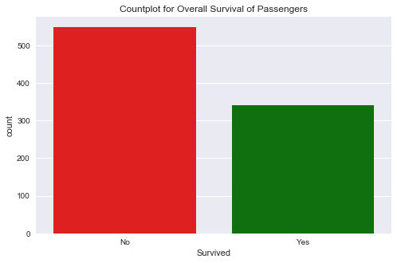

```python
print(titanic_df['Survived'].value_counts(normalize=True))
plt.figure(figsize=(8,5))
s=sns.countplot('Survived',data=titanic_df,palette={0:'r',1:'g'})
s.set_xticklabels(["No","Yes"])
s.set(title="Countplot for Overall Survival of Passengers")
```

Above that majority dies and only **38%** survive in this data set. Let's begin to analyse the different factors that may determine the likelihood for survival.

**Gender Distribution**

```
male      0.647587
female    0.352413
Name: Sex, dtype: float64
```

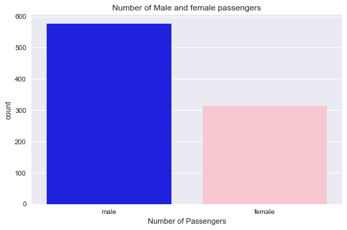

```python
print(titanic_df['Sex'].value_counts(normalize=True))
plt.figure(figsize=(8,5))
s_sex=sns.countplot('Sex',data=titanic_df,palette={'male':'blue','female':'pink'})
s_sex.set(title="Number of Male and female passengers")
s_sex.set_xlabel("Number of Passengers")
```

The plot shows the majority of passengers onboard are male.

**Survival by Gender**

```python
titanic_df['Survived'].groupby(titanic_df['Sex']).value_counts(normalize=True)
```

```
Sex     Survived
female  1           0.742038
        0           0.257962
male    0           0.811092
        1           0.188908
Name: Survived, dtype: float64
```

**74% of females** survived where as only **19% of males** survived.

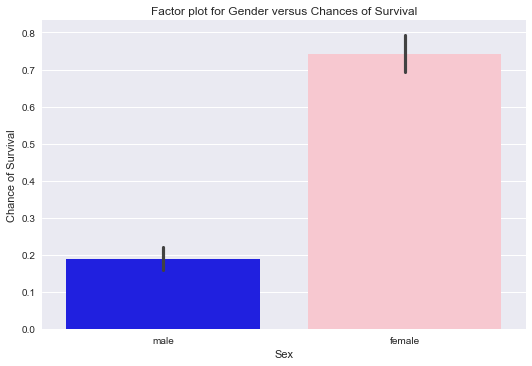

```python
plt.figure(figsize=(8,5))
g=sns.factorplot('Sex','Survived',data=titanic_df,kind='bar',palette={'male':'blue','female':'pink'},size=5,aspect=1.5)
g.set_ylabels("Chance of Survival")
g.set(title="Factor plot for Gender versus Chances of Survival")
```

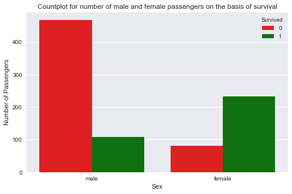

```python
plt.figure(figsize=(8,5))
g=sns.countplot('Sex', hue='Survived',data=titanic_df,palette={0:'r',1:'g'})
g.set_ylabel("Number of Passengers")
g.set(title="Countplot for number of male and female passengers on the basis of survival")
```

The above two plots speak for themseleves. Women had greater chance of survival as compared to men, this confirms our assumption that women were saved first. Another, important factor that made survival more likely was **Age**.Let's look at the distirbution of Age versus number of passengers who survived/not survived.

# Age

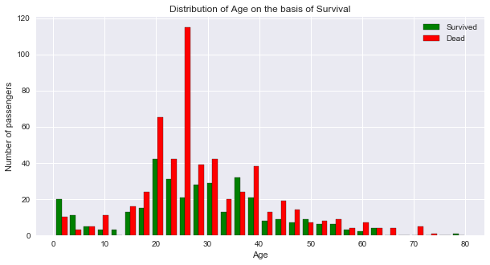

```python
%matplotlib inline
figure = plt.figure(figsize=(10,5))
plt.hist([titanic_df[titanic_df['Survived']==1]['Age'],titanic_df[titanic_df['Survived']==0]['Age']],
         bins=30,stacked=False,label = ['Survived','Dead'],color=['g','r'],edgecolor='black')
plt.xlabel('Age')
plt.ylabel('Number of passengers')
plt.title('Distribution of Age on the basis of Survival')
plt.legend()
```

The plot above shows passengers aged less tha 10 are more likely to survive, passengers greater than 12 but less than 50 were less likely to survive. We can also see that older passengers have been rescued too. They can be female passengers, nanny's travelling with babies or royalties. We can't say!

I will now explore the Age variable more on the basis of Sex and Survival. Assuming passenger aged between 0 to 18 as a child and above as an adult.Let's check if the children were more likely to survive.

```
Child  Survived
0      0           0.638817
       1           0.361183
1      1           0.539823
       0           0.460177
Name: Survived, dtype: float64
```

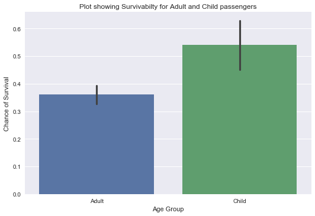

```python
#Creating new variable "Child". Child=1 if age<18 and 0 otherwise (Adult)
titanic_df["Child"]=titanic_df['Age'].map(lambda x: 1 if x<18 else 0)
print(titanic_df["Survived"].groupby(titanic_df["Child"]).value_counts(normalize=True))
plt.figure(figsize=(8,5))
g=sns.factorplot('Child','Survived',data=titanic_df,kind='bar',size=5,aspect=1.5)
g.set_ylabels("Chance of Survival")
g.set_xlabels("Age Group")
g.set_xticklabels(['Adult','Child'])
g.set(title="Plot showing Survivabilty for Adult and Child passengers")
```

As we can see, survival rate for children is **54%** but for an adult is only **36%**. To confirm our initial assumption the women and children were saved first,Let's look at Age spread for male and female passengers who survived/not survived.

```python
titanic_df.groupby(['Sex','Survived']).agg({'Age':{'Median':'median','Mean':'mean','Maximum':'max', 'Minimum':'min',
                                                   'Child': lambda x:(x<18).sum(),'Adult': lambda x:(x>=18).sum()}})
```

| Sex | Survived | Age Median | Age Mean | Age Maximum | Age Minimum | Age Child | Age Adult |
| --- | --- | --- | --- | --- | --- | --- | --- |
| female | 0 | 21.5 | 24.302469 | 57.0 | 2.00 | 17.0 | 64.0 |
|  | 1 | 27.0 | 28.289700 | 63.0 | 0.75 | 38.0 | 195.0 |
| male | 0 | 26.0 | 30.678419 | 74.0 | 1.00 | 35.0 | 433.0 |
|  | 1 | 27.0 | 27.721743 | 80.0 | 0.42 | 23.0 | 86.0 |

Here we see that average age for female survivors(28) is not far from that of male survivors(27). Notice that majority of the female children survived but the majority of male children died.

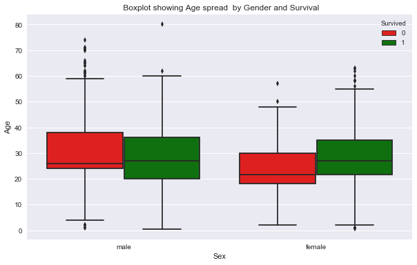

```python
plt.figure(figsize=(10,6))
s=sns.boxplot(x='Sex',y='Age',data=titanic_df,hue="Survived",palette={0:'r',1:'g'})
s.set(title=' Boxplot showing Age spread  by Gender and Survival')
```

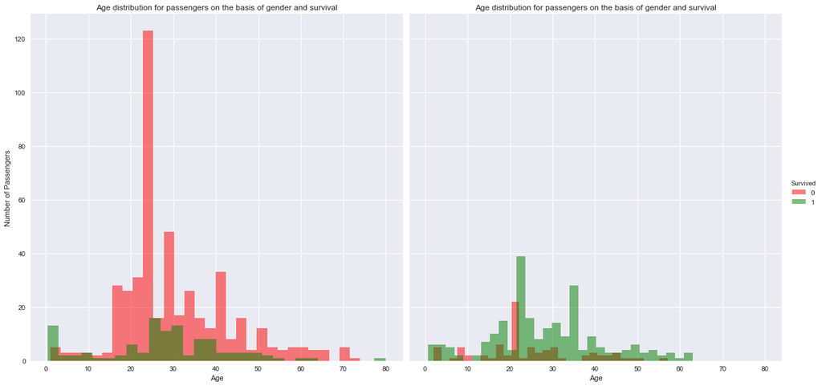

```python
g=sns.FacetGrid(titanic_df,col='Sex',hue='Survived',palette={0:'r',1:'g'},size=8,aspect=1)
s=g.map(plt.hist,'Age',bins=30,alpha=0.5).add_legend()
s.set_ylabels('Number of Passengers')
s.set(title="Age distribution for passengers on the basis of gender and survival")
```

At this stage, we can infer that **women and children** were more likely to survive. We see that average age for survivors in case of male and female passengers is very close; 28 and 27 but Older men account for slightly more of male non-survivors whereas older women account more for female survivors(as shown in plots above). However, majority of the male passengers aged less than 18 did not survive. This means Age and Sex were not the only factors affecting the chances of survival. Maybe Socio-Economic class played an important role as well. It is possible that majority of the older male passengers and children from the male gender group were travelling in lower class and were not given priority. Further, It is likely that older women(27 or above) were travelling with one or more children or maybe most of the older female passengers travelled in upper class.

To answer these questions, let's explore the relation of class of travel with other variables.

# Class of travel (Pclass)

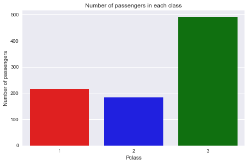

```python
plt.figure(figsize=(8,5))
pal={1:'r',2:'b',3:'g'}
sp=sns.countplot(x='Pclass',data=titanic_df,palette=pal)
sp.set(title='Number of passengers in each class')
sp.set_ylabel("Number of passengers")
```

We can see that maximum number of passengers were travelling in class 3. The probablilty of survival in each class is shown in the plot below.

```
Pclass  Survived
1       1           0.629630
        0           0.370370
2       0           0.527174
        1           0.472826
3       0           0.757637
        1           0.242363
Name: Survived, dtype: float64
```

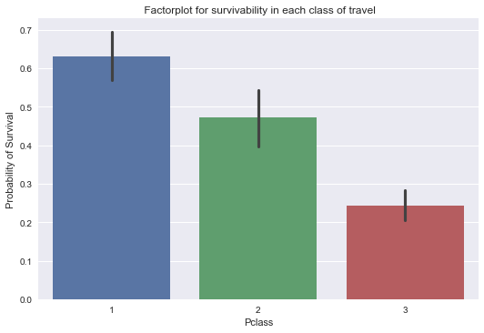

```python
#Survival by class of the passenger
print(titanic_df['Survived'].groupby(titanic_df['Pclass']).value_counts(normalize=True))

#Pclass vs Survived
s=sns.factorplot(x="Pclass",y="Survived",data=titanic_df,kind='bar',size=5,aspect=1.5)
s.set(title=" Factorplot for survivability in each class of travel")
s.set_ylabels('Probability of Survival')
```

Looking at the plots we can see majority of the passengers were travelling in lower class and most of them died. Chances of survival seem to increase with socioeconomical status, class 1 passengers have **63%**,class 2 has **47%** and class 3 has the least chance of survival at **24%**. Overall, women stand a higher chance of survival as compared to men based on previous findings.Let's break down the chances of survival in each class by gender to find the contribution of socioeconomic status in the overall survivability.

```
Sex     Pclass  Survived
female  1       1           0.968085
                0           0.031915
        2       1           0.921053
                0           0.078947
        3       0           0.500000
                1           0.500000
male    1       0           0.631148
                1           0.368852
        2       0           0.842593
                1           0.157407
        3       0           0.864553
                1           0.135447
Name: Survived, dtype: float64
```

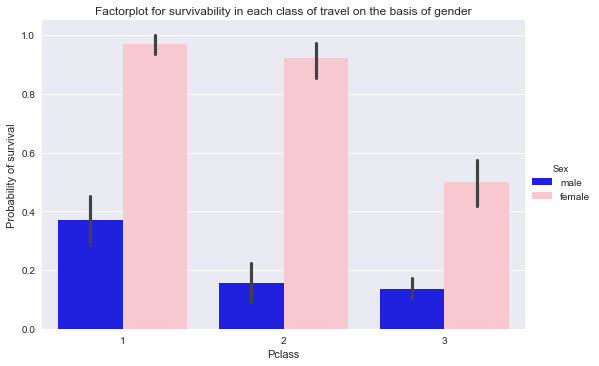

```python
#Chances of survival on the basis of Gender and Class
pclass_sex_prob=titanic_df.groupby(['Sex','Pclass'])
print(pclass_sex_prob['Survived'].value_counts(normalize=True))
#Pclass vs Sex vs Survived
pclass_sex = sns.factorplot("Pclass", "Survived",order=[1,2,3],data=titanic_df
,hue='Sex', kind='bar',size=5,aspect=1.5,palette={'male':'b','female':'pink'})
pclass_sex.set_ylabels("Probability of survival")
pclass_sex.set(title="Factorplot for survivability in each class of travel on the basis of gender")
```

Above caluclations reveal female passengers in class 1(97%) and 2(92%) have maximum chance of survival compared to any other male or female passenger. Female passengers in class 3 have an equal distribution of survivors and non survivors. In case of male passengers, class 1 is the highest at 36% and class 2 and class 3 are quite low at 16% and 13% respectively.

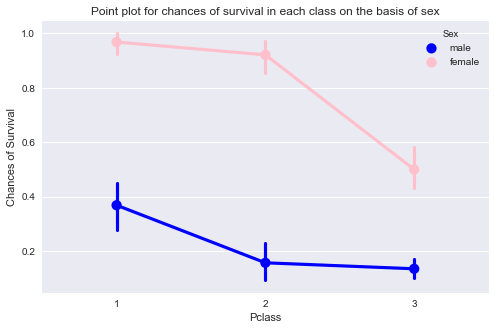

```python
#Pclass vs Sex vs Survived
plt.figure(figsize=(8,5))
g=sns.pointplot(x="Pclass", y="Survived", hue="Sex", data=titanic_df,
              palette={"male": "b", "female": "pink"})
g.set_ylabel("Chances of Survival")
g.set(title="Point plot for chances of survival in each class on the basis of sex")
```

We can see that females were more likely to survive in each class with almost 100% chance of survival if they belonged to upper class. Men had low chances of survival irrespective of their scoioeconomic status due to lifeboat priority to women and children. It is not much of s surprise that Class 1 (upper class) had the highest survival rate, females at 97% and males at 36% and Class 3 (poor class) had the lowest survival rate, females about 50% and males at 13% surivival rate. Next, let's look at the age distribution in each class for survivors and non survivors.

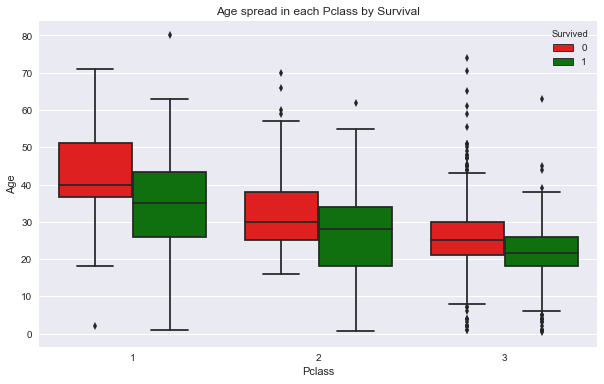

```python
plt.figure(figsize=(10,6))
s=sns.boxplot(x='Pclass',y='Age',data=titanic_df,hue="Survived",palette={0:'r',1:'g'})
s.set(title='Age spread in each Pclass by Survival')
```

Looking at each Pclass we can see that the inner-quartile ranges for boxplots favor the younger side and their non-survior counterpart IQR favours older passengers in every class. I willl further divide the age group into children and adults and analysis survivabilty on the basis of Pclass.

| Child | Key |
| --- | --- |
| 0 | Adult |
| 1 | Child |

```
Child  Pclass  Survived
0      1       1           0.612745
               0           0.387255
       2       0           0.590062
               1           0.409938
       3       0           0.782082
               1           0.217918
1      1       1           0.916667
               0           0.083333
       2       1           0.913043
               0           0.086957
       3       0           0.628205
               1           0.371795
Name: Survived, dtype: float64
```

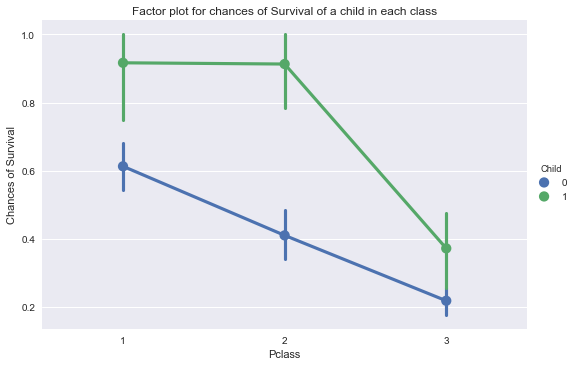

```python
print(titanic_df.groupby(['Child','Pclass'])['Survived'].value_counts(normalize=True))
s=sns.factorplot(x="Pclass", y="Survived", hue="Child", kind='point',data=titanic_df,legend=True,size=5,aspect=1.5)
s.set_ylabels("Chances of Survival")
s.set(title="Factor plot for chances of Survival of a child in each class")
```

Children in class 1 and 2 show a very high probabilty of survival, 92% and 91% respectively. Unexpectedly, children travelling in class 3 have probabilty of survival close to class 3 Adults at 37% and 22% respectively. Next, I will visualise all three factors age, sex and pclass that are assumed to affect the chances of survival on a single plot.

[figure not shown]

```python
pal={0:'r',1:'g'}
g=sns.FacetGrid(titanic_df,col="Pclass",size=8,aspect=0.541)
g=g.map(sns.boxplot,x="Sex", y="Age",hue="Survived",data=titanic_df,palette=pal).add_legend()
g.set_ylabels('Age')
g.set(title='Box plot for Age vs Sex vs Pclass vs Survived')
```

In case of male passengers in the IQR for non-survivors favor older passengers whereas we see the opposite in case of female passengers, IQR for survivors favor older passengers.

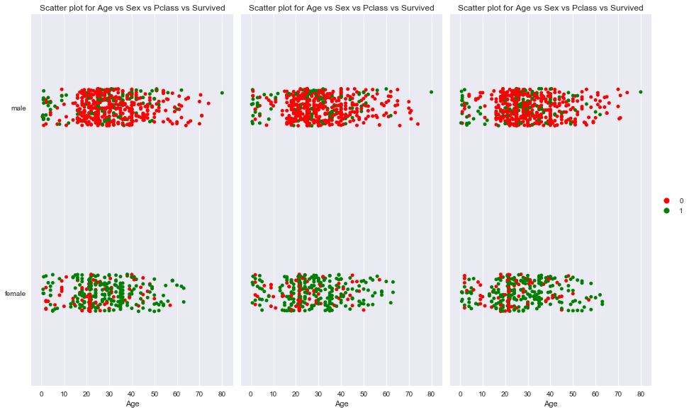

```python
#Pclass vs Age vs Sex vs Survived
pal={0:'r',1:'g'}
g=sns.FacetGrid(titanic_df,col="Pclass",size=8,aspect=0.541)
g=(g.map(sns.stripplot,x="Age", y="Sex",hue="Survived",data=titanic_df,jitter=True,palette=pal)).add_legend()
g.set_xlabels("Age")
g.set(title='Scatter plot for Age vs Sex vs Pclass vs Survived')
```

Before I start exploring other variables in the dataset,computing correlations between coloumns is a good idea to explore the dataset and find out what coloumns are related to the coloumn we care about("Survived"). The closer to 0 the correlation the weaker the connection.The closer to 1, the stronger the positive correlation and the closer to -1 the stronger the negative correlation.

**Correlation**

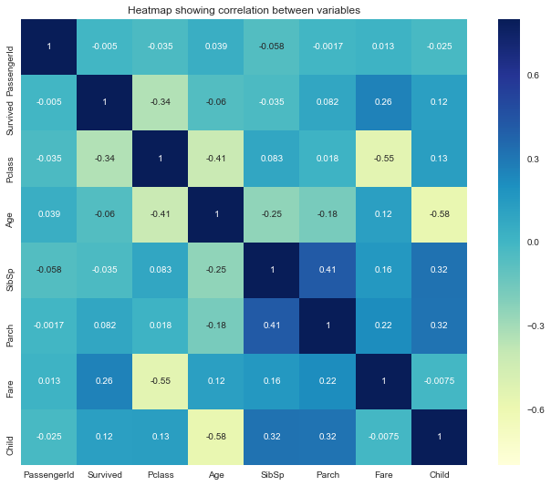

```python
#Correlation heat map
f, ax = plt.subplots(figsize=(12, 9))
s=sns.heatmap(titanic_df.corr(),annot=True,vmax=.8, square=True,cmap="YlGnBu")
s.set(title="Heatmap showing correlation between variables")
```

The heatmap above shows none of the variables are highly correlated. This means each variable holds unique information and is a potential angle to explore.

**Travelling alone or with Family**

Creating a new variable "Family Size" by adding variables "SibSp" and "Parch".

```python
titanic_df["Family Size"]=titanic_df["SibSp"]+titanic_df["Parch"]+1
print(titanic_df.groupby("Family Size")["Survived"].value_counts(normalize=True))
```

```
Family Size  Survived
1            0           0.696462
             1           0.303538
2            1           0.552795
             0           0.447205
3            1           0.578431
             0           0.421569
4            1           0.724138
             0           0.275862
5            0           0.800000
             1           0.200000
6            0           0.863636
             1           0.136364
7            0           0.666667
             1           0.333333
8            0           1.000000
11           0           1.000000
Name: Survived, dtype: float64
```

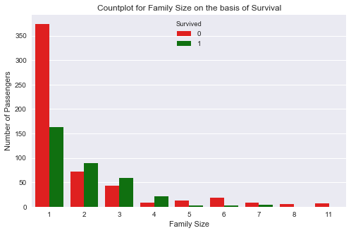

```python
plt.figure(figsize=(8,5))
s=sns.countplot("Family Size",data=titanic_df,hue="Survived",palette={0:'r',1:'g'})
s.set_ylabel('Number of Passengers')
s.set(title='Countplot for Family Size on the basis of Survival')
```

Number of survivors travelling alone were less than the number of non-survivors travelling alone. As the family size increases from 2 to 4 the number of surviors are more as compared to non-survivors. Also, we see a decline in the number of survivors for family size 5 to 7 and absolutely no survivors in families of 8 or 11 members.

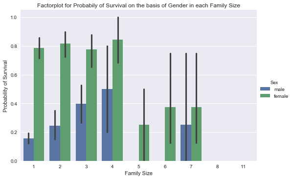

```python
s_fam=sns.factorplot(x="Family Size",y="Survived",hue="Sex",data=titanic_df,kind='bar',size=5,aspect=1.5)
s_fam.set(title="Factorplot for Probabily of Survival on the basis of Gender in each Family Size")
s_fam.set_ylabels('Probability of Survival')
```

The above factorplot confirms female passengers travelling with any number of family members(except 8 or 11)had more chance of survival.

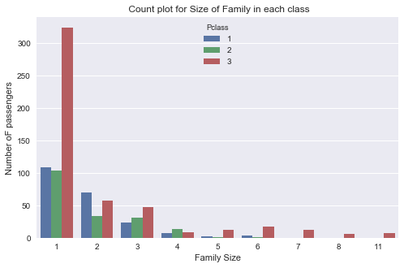

```python
plt.figure(figsize=(8,5))

s=sns.countplot(x="Family Size",hue="Pclass",data=titanic_df)
s.set_ylabel("Number oF passengers")
s.set(title=" Count plot for Size of Family in each class")
```

In class 3 most of the passengers were travelling alone. In class 1 and 2 family size range from 1 to 6, It makes sense that most of the passengers travelling in class 3 died and most of them were travelling alone. Next, I have created a new variable 'IsAlone' to identify the proportion of male and female passengers travelling alone or with family.

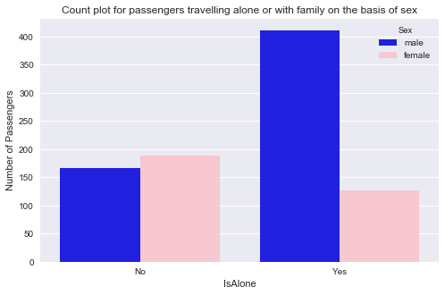

```python
#creating a variable 'IsAlone'=1 if 'family Size' is 1 and 0 otherwise
titanic_df['IsAlone']=titanic_df['Family Size'].map(lambda x: 1 if x==1 else 0)
plt.figure(figsize=(8,5))
s_alone=sns.countplot("IsAlone",data=titanic_df,hue="Sex",palette={'male':'b','female':'pink'})
s_alone.set_xticklabels(['No','Yes'])
s_alone.set_ylabel('Number of Passengers')
s_alone.set(title='Count plot for passengers travelling alone or with family on the basis of sex')
```

We see that females were more likely to be travelling with family and this connects to our inference made earlier that women and children were most likely to survive.

**Embarked**

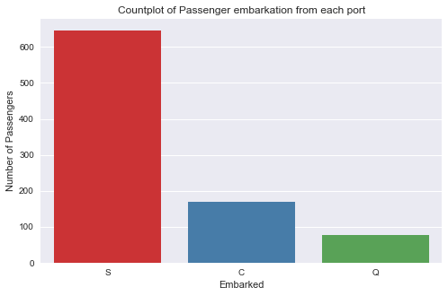

```python
plt.figure(figsize=(8,5))
s=sns.countplot(x="Embarked",data=titanic_df,palette="Set1")
s.set_ylabel('Number of Passengers')
s.set(title='Countplot of Passenger embarkation from each port')
```

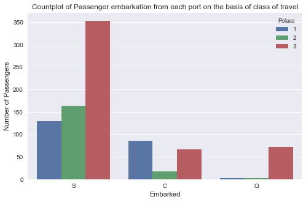

```python
plt.figure(figsize=(8,5))
s=sns.countplot('Embarked',data=titanic_df,hue='Pclass')
s.set_ylabel('Number of Passengers')
s.set(title='Countplot of Passenger embarkation from each port on the basis of class of travel')
```

Most of the passengers boarded from Southhampton and were travelling class 3.Let's have a close look at the survivability of passengers embarked from different locations.

```
Embarked  Survived
C         1           0.553571
          0           0.446429
Q         0           0.610390
          1           0.389610
S         0           0.660991
          1           0.339009
Name: Survived, dtype: float64
```

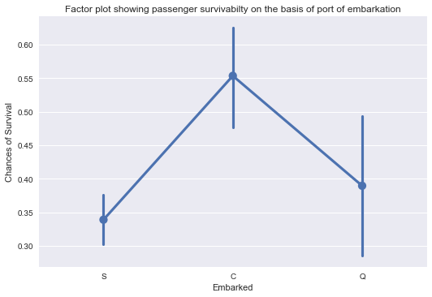

```python
print(titanic_df.groupby('Embarked')['Survived'].value_counts(normalize=True))
s=sns.factorplot(x='Embarked',y='Survived',data=titanic_df,size=5,aspect=1.5)
s.set_ylabels('Chances of Survival')
s.set(title='Factor plot showing passenger survivabilty on the basis of port of embarkation')
```

Passengers who emabrked from southampton had lowest chances of survival at 34%, Cherbourg had 55% and Queenstown had 39%. Notice that number of passengers travelling in class 1 is more in the case where southampton is the port of embarkation compared to when it is Cherbourg, but the survivability of passenges is the highest in case of Cherbourg and lowest in case of Southampton. The number of class 3 passengers embarking from each port bring the total chances of survival down, as Southampton has the highest number of class 3 passengers followed by Queenstown and Cherbourg.

# 4. Conclusion

While the Titanic was sinking, the officers famously prioritized who was allowed in a lifeboat with the strict maritime tradition of evacuating women and children first. The statistical calculation results clearly reflect the first part of this policy as, across all classes, women were much more likely to survive than the men. We can also see that the women were younger than the men on average and were more likely to be traveling with family. Also, being a women, being a child, being in 1st class and travelling with family were all factors that could boost the chances of survival.

# 5. Limitations of this analysis

- The dataset has missing values in Age column and the missing age values are imputed with the median. Below is the difference between dropped missing values and imputed age values.

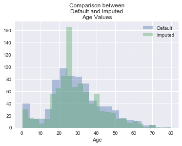

```python
titanic_df2=pd.read_csv('C:/Users/609220489/Documents/Udacity/titanic-data.csv')
sns.distplot(titanic_df2.Age.dropna(), kde = False, label = 'Default')
sns.distplot(titanic_df['Age'], kde = False, label = 'Imputed')
plt.title('Comparison between\nDefault and Imputed\nAge Values')
plt.legend()
```

As we see median value is massively over represented and has changed the shape of the Age distribution quite a bit. Introducing 177 more ages will infulence the statistical calculations for the Survival in terms of Age distribution in each class and genders.

- Majority of the cain values are missing in this dataset. Cabin information can reveal more interesting insights into the surival factors for this sample of popultion for example, the which cabin had more percentage of survivors, the cabin location can reveal if the likelihood of passengers to reach the deck and get on to the life boats.
- This Analysis is purely based on statistical calculations and correlation observations with no inferential statistical methods applied. There is no definite null hypothesis for survivabilty.These statistical testing is used to make inferences about larger population from sample data(our data set of 891 passengers). In other words, we can say that inferential statistical measures help us to make judgement for population on the basis of insights generated from sample,with statistical testing of a particular hypothesis is that we can approach a clearer statistically significant relationship between aspects of the dataset.
- Other factors affecting the Survivability- Measures used to collect the data. Based on Statistical Consultants Ltd (http://www.statisticalconsultants.co.nz/blog/titanic-survival-data.html), the Titanic survival data set has some uncertainties due to several reasons like double counting caused by people using aliases, the final passenger list not having been updated to account for every person who cancelled their trip, some people died (as a result of injuries or exposure) after they were picked up by the rescue ship (the RMS Carpathia)

# 6. Recommendations

**Statistical Tests**

**Chi-Square Test**: This test is used to derive the statistical significance of relationship between two categorical variables.Chi-square is based on the difference between the expected and observed frequencies in one or more categories in the two-way table. It returns probability for the computed chi-square distribution with the degree of freedom.

Probability of 0: It indicates that both categorical variable are dependent

Probability of 1: It shows that both variables are independent.

Probability less than 0.05: It indicates that the relationship between the variables is significant at 95% confidence.

```python
import scipy as sp
men=titanic_df[titanic_df.Sex =='male']
women=titanic_df[titanic_df.Sex =='female']
men_Survived = men[men.Survived == 1].count()['Sex']
men_Died = men[men.Survived == 0].count()['Sex']
women_Survived = women[women.Survived == 1].count()['Sex']
women_Died = women[women.Survived == 0].count()['Sex']
# Table for calculation - Chi-Square Test of independence Gender and survival
men_women_survived = np.array([[men_Survived, men_Died],[women_Survived, women_Died]])
sp.stats.chi2_contingency(men_women_survived)
```

```
(260.71702016732104,
 1.1973570627755645e-58,
 1,
 array([[ 221.47474747,  355.52525253],
        [ 120.52525253,  193.47474747]]))
```

**p value :1.1973570627755645e-58**

```python
child=titanic_df[titanic_df.Child ==1]
adult=titanic_df[titanic_df.Child ==0]
childSurvived = child[child.Survived == 1].count()['Child']
childDied = child[child.Survived == 0].count()['Child']
adultSurvived = adult[adult.Survived == 1].count()['Child']
adultDied = adult[adult.Survived == 0].count()['Child']
# Table for calculation - Chi-Square Test of independence Age group and survival
child_adult_survived = np.array([[childSurvived, childDied],[adultSurvived, adultDied]])
sp.stats.chi2_contingency(child_adult_survived)
```

```
(12.569031659705169,
 0.00039219174140767127,
 1,
 array([[  43.37373737,   69.62626263],
        [ 298.62626263,  479.37373737]]))
```

**p value =0.00039219174140767127**

Since their p values < 0.05, we can infer, Sex and Child are highly significant variables. We can further apply statistical test to identify significant variables that can be included in the prediction model.

# 7. Resources

- https://www.kaggle.com/c/titanic
- http://seaborn.pydata.org/tutorial.html
- http://stattrek.com/chi-square-test/independence.aspx
- http://www.statisticalconsultants.co.nz/blog/titanic-survival-data.html
- https://docs.scipy.org/doc/scipy-0.15.1/reference/generated/scipy.stats.chi2_contingency.html
- http://www.csun.edu/~amarenco/Fcs%20682/When%20to%20use%20what%20test.pdf